# ICE Annina 10x sequencing analysis - generate metacells for DEA/GSEA

Author

Vladyslav Korobeynyk at Jessberger/Robinsonlab, UZH

Published

October 5, 2026

**Note**

**What this script does:** loads the integrated/annotated organoid Seurat object from `01_organoid_QC_processing_integration.qmd`, generates metacells (bootstrapped pseudobulk profiles) per celltype for each dataset grouping (COp1 10w, COp1 4m, COp2 4dpi+4wpi pooled, and COp2 4dpi/4wpi separately for IN/EN), runs ICE-vs-wt DESeq2 DEA and GSEA (GO Biological Process) on each, and saves the resulting metacell objects and DEA/GSEA tables for use in later scripts (organoid single-cell analysis, and the human/organoid ML prediction scripts). It also runs a few “all datasets combined” DEA and GSEA analyses to look at the ICE-vs-wt signature across the whole organoid cohort.

# libraries

```r
options(scipen = 1, digits = 3)
set.seed(1)

suppressMessages({
  library(dplyr)
  library(Seurat)
  library(edgeR)
  library(harmony)
  library(stringr)
  library(stringi)
  library(genekitr)
  library(ggplot2)
  library(geneset)
  library(scater)
  library(magrittr)
  library(SingleCellExperiment)
  library(DT)
  library(EnhancedVolcano)
  library(cluster)
  library(DESeq2)
  library(pheatmap)
  library(rrvgo)
  library(tidyr)
  library(openxlsx)
  library(ggpubr)
  library(patchwork)
})

# Load local pipeline utilities
source(params$qc_pipeline_functions_path)
source(params$helper_functions_path)

# Output directory path configurations
object_storage_path = params$object_storage_path
gsea_results_path = params$gsea_results_path
DEA_results_path = params$dea_results_path

dir.create(DEA_results_path, recursive = TRUE, showWarnings = FALSE)
dir.create(gsea_results_path, recursive = TRUE, showWarnings = FALSE)

gs = geneset::getGO(org = "human", ont = "bp")
```

# Load object

```r
harmonized_seurat = readRDS(file.path(object_storage_path , "SO_integratedHarmony_alldatasetsTogether_organoids.RDS"))
harmonized_seurat_COp1_10w = subset(harmonized_seurat, Protocol_maturation_stage == "COp1_10w")
harmonized_seurat_COp1_4m = subset(harmonized_seurat, Protocol_maturation_stage == "COp1_4m")
harmonized_seurat_COp2_4dpi_4wpi = subset(harmonized_seurat, Protocol == "COp2")
```

# Helper functions for this script

```r
#' Generate metacells + per-celltype DESeq2 DEA (ICE vs wt) for a Seurat subset
#' @param SO Seurat object already subset to the dataset/timepoint grouping of interest
#' @param celltypes character vector of Celltype values to loop over
#' @return named list (by celltype) of list(sce = , markers = , DESeq2_lst = )
generate_metacells_dea_per_celltype = function(SO, celltypes, amount_of_cells_to_aggregate, n_metacells_generate) {
  lapply(celltypes, function(ct) {
    sce = create_metacells(
      SO = subset(SO, Celltype == ct),
      amountOfCells_toAggregate = amount_of_cells_to_aggregate,
      N_metacells_generate = n_metacells_generate
    )
    sce$phenotype = as.factor(sce$phenotype)

    DESeq2_lst = metacell_DESeq2_DEA(
      sce = sce, phenotype_column = "phenotype", dataset_column = "dataset",
      design_formula = as.formula("~ phenotype"), title_corHeatmap = paste0("metacell correlation ", ct),
      contrast = c("phenotype", "ICE", "wt"), organism = "organoid"
    )

    markers = DESeq2_lst$markers %>% na.omit()
    list(sce = sce, markers = markers, DESeq2_lst = DESeq2_lst)
  }) %>% setNames(celltypes)
}

#' Run GSEA on each celltype's DEA markers, and summarize the (relative) number of
#' significant GO terms found per celltype
#' @return list(out = per-celltype GSEA results, goterm_summary = data.frame for plotting)
summarize_gsea_per_celltype = function(metacell_list, gs, n_pathways) {
  out = lapply(metacell_list, function(x) {
    sign_markers = x$markers %>% filter(padj < params$dea_padj_threshold)
    gsea = gsea_analysis(markers = x$markers, cluster = "trending clusters", gs = gs,
                          n_pathways = n_pathways, plot_type = "none")
    list(sign_markers = sign_markers, n_sign_markers = nrow(sign_markers), gsea = gsea)
  })

  goterm_summary = lapply(out, function(x) {
    if (is.list(x$gsea)) nrow(x$gsea$gsea_df)
  }) %>%
    Filter(Negate(is.null), .) %>%
    as.data.frame() %>%
    t() %>%
    as.data.frame() %>%
    tibble::rownames_to_column("celltype") %>%
    dplyr::rename(n = V1) %>%
    mutate(relative_n = n / sum(n))

  list(out = out, goterm_summary = goterm_summary)
}

#' Show PCA/MA diagnostics for a metacell DESeq2 result, save the markers table, and
#' plot expression of the top genes by padj across phenotype
plot_dea_tab = function(DESeq2_lst, output_csv_path, n_top_genes = 4) {
  print(DESeq2_lst$plt_phenotype)
  print(DESeq2_lst$plt_dataset)

  markers = DESeq2_lst$markers %>% na.omit()
  write.csv(markers, output_csv_path)

  DESeq2::plotMA(DESeq2_lst$res)
  with(markers %>% filter(padj < params$dea_padj_threshold) %>% head(10), {
    text(baseMean, avg_log2FC, labels = gene, pos = 3, cex = 1)
    segments(baseMean, avg_log2FC, baseMean, avg_log2FC, col = "gray60")
  })

  # After a VST transformation, values are on a scale where variance is stabilized and no
  # longer mean-dependent, so they're comparable across genes regardless of original variance.
  vst = DESeq2_lst$vst_transformed_deseq2
  dds = DESeq2_lst$dds
  expr = assay(vst)

  genes = markers %>% arrange(padj) %>% dplyr::slice(1:n_top_genes) %>% pull(gene)

  df = expr[genes, , drop = FALSE] %>%
    as.data.frame() %>%
    tibble::rownames_to_column("gene") %>%
    pivot_longer(-gene, names_to = "sample", values_to = "expression") %>%
    left_join(as.data.frame(colData(dds)) %>% tibble::rownames_to_column("sample"), by = "sample")

  print(
    ggplot(df, aes(x = phenotype, y = expression)) +
      geom_boxplot() +
      geom_jitter(width = 0.2, size = 1.5, alpha = 0.6) +
      facet_wrap(~ gene, scales = "free_y") +
      labs(y = "VST normalized expression")
  )

  markers
}

#' Run GSEA on a saved DEA markers CSV, write up/down GO term tables, plot the reduced-GO treemap
run_gsea_tab = function(markers_csv_path, gs, n_pathways, up_txt_path, down_txt_path, title_label) {
  markers = read.csv(markers_csv_path, row.names = 1)
  gsea = gsea_analysis(markers = markers, cluster = "trending clusters", gs = gs,
                        n_pathways = n_pathways, plot_type = "none")

  write.table(gsea$gsea_df %>% filter(NES > 0) %>% select(hsapiens_BP_ID, p.adjust),
              up_txt_path, row.names = FALSE, quote = FALSE)
  write.table(gsea$gsea_df %>% filter(NES < 0) %>% select(hsapiens_BP_ID, p.adjust),
              down_txt_path, row.names = FALSE, quote = FALSE)

  plot_ReducedGOterms(gsea_df = gsea$gsea_df, title_label = title_label)
}

#' Generate metacells + DEA for a single celltype restricted to one Protocol timepoint
#' (used for the COp2 4dpi/4wpi IN/EN objects later for ML prediction).
generate_metacell_by_timepoint = function(SO, celltypes, timepoint, amount_of_cells_to_aggregate,
                                           n_metacells_generate, dea_csv_prefix) {
  lapply(celltypes, function(ct) {
    cells_keep = colnames(SO)[SO$Celltype == ct & SO$timepoint == timepoint]

    sce = create_metacells(
      SO = subset(SO, cells = cells_keep),
      amountOfCells_toAggregate = amount_of_cells_to_aggregate,
      N_metacells_generate = n_metacells_generate
    )
    sce$phenotype = as.factor(sce$phenotype)

    DESeq2_lst = metacell_DESeq2_DEA(
      sce = sce, phenotype_column = "phenotype", dataset_column = "dataset",
      design_formula = as.formula("~ phenotype"), contrast = c("phenotype", "ICE", "wt"),
      organism = "organoid"
    )

    markers = DESeq2_lst$markers %>% na.omit()
    write.csv(markers, paste0(dea_csv_prefix, "_", ct, "_COp2_", timepoint, "_organoids.csv"))

    list(sce = sce, sampleCor_heatmap = DESeq2_lst$heatmap)
  }) %>% setNames(celltypes)
}

#' Restrict a list of SingleCellExperiments to their shared genes and cbind them together
merge_sces_common_genes = function(sce_list) {
  common_genes = Reduce(intersect, lapply(sce_list, rownames))
  message("Number of shared genes across ", length(sce_list), " objects: ", length(common_genes))
  subsetted = lapply(sce_list, function(sce) sce[common_genes, ])
  do.call(cbind, subsetted)
}

#' Generate metacells for one celltype, pooling all datasets with a 4dpi/4wpi timepoint
#' annotation together (regardless of protocol/maturation stage)
generate_metacell_celltype_timepointComparison = function(SO, celltype, amount_of_cells_to_aggregate, n_metacells_generate) {
  cells_keep = colnames(SO)[SO$Celltype == celltype & SO$timepoint %in% c("4dpi", "4wpi")]
  sce = create_metacells(
    SO = subset(SO, cells = cells_keep),
    amountOfCells_toAggregate = amount_of_cells_to_aggregate,
    N_metacells_generate = n_metacells_generate
  )
  sce$phenotype = as.factor(sce$phenotype)
  sce$timepoint = factor(sce$timepoint, levels = c("4dpi", "4wpi")) # 4dpi = reference
  sce
}

#' ICE vs wt effect specifically at one timepoint (Wald). Positive avg_log2FC = higher in ICE.
get_phenotype_effect_at_timepoint = function(sce, reference_timepoint, design_formula) {
  sce$timepoint = relevel(as.factor(sce$timepoint), ref = reference_timepoint)
  dds = DESeqDataSetFromMatrix(counts(sce), colData = colData(sce), design = design_formula)
  dds = DESeq(dds)
  results(dds, contrast = c("phenotype", "ICE", "wt")) %>%
    as.data.frame() %>%
    dplyr::rename("avg_log2FC" = "log2FoldChange") %>%
    mutate(gene = rownames(.))
}

#' LRT: does the phenotype (ICE vs wt) effect differ by timepoint (4dpi vs 4wpi)?
run_timepoint_phenotype_interaction_dea = function(sce, design_full, design_reduced) {
  dds_full = DESeqDataSetFromMatrix(counts(sce), colData = colData(sce), design = design_full)
  dds_full = DESeq(dds_full, test = "LRT", reduced = design_reduced)

  # NOTE: for a multi-coefficient LRT, avg_log2FC does not reflect a clean "higher in X vs Y" direction - only padj
  # from this table should be interpreted (does the phenotype effect differ by
  # timepoint).
  markers = results(dds_full) %>%
    as.data.frame() %>%
    dplyr::rename("avg_log2FC" = "log2FoldChange") %>%
    mutate(gene = rownames(.)) %>%
    filter(!is.na(padj))

  list(dds = dds_full, markers = markers)
}
```

# Generate metacells + DEA | COp1 10w | per Celltype

**Tip**

Why Metacells? Single-cell RNA-seq data is notoriously sparse and prone to high dropout rates. Aggregating transcriptomic profiles into metacells allows us to perform more sensitive, un-biased pseudobulk DEA testing while preserving sample-level replicate fidelity.

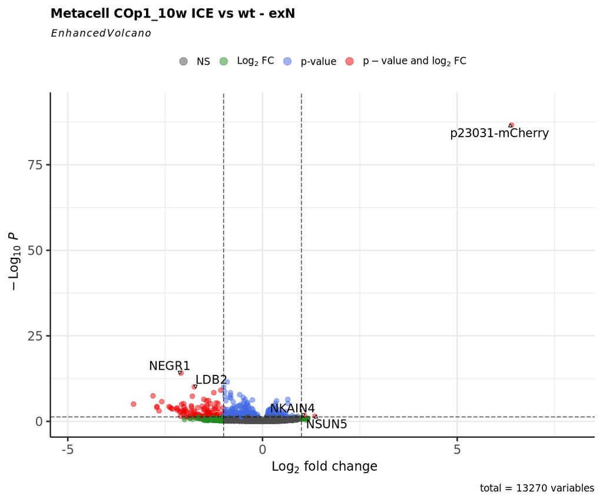

```r
celltypes = unique(harmonized_seurat_COp1_10w$Celltype)

sce_metacells_alldatasets_perCT_10w = generate_metacells_dea_per_celltype(
  harmonized_seurat_COp1_10w, celltypes, params$amount_of_cells_to_aggregate, params$n_metacells_generate
)

saveRDS(sce_metacells_alldatasets_perCT_10w , file.path(object_storage_path , "metacell_sce_allCelltypes_COp1_10w.RDS"))

markers = sce_metacells_alldatasets_perCT_10w$exN$markers
EnhancedVolcano(markers,
              lab = rownames(markers),
              x = 'avg_log2FC',
              y = 'padj',
              title = paste0('Metacell COp1_10w ICE vs wt - ', "exN"),
              pCutoff = 0.05,
              FCcutoff = 1,
              pointSize = 3.0,
              labSize = 6.0,
              drawConnectors = TRUE)
```

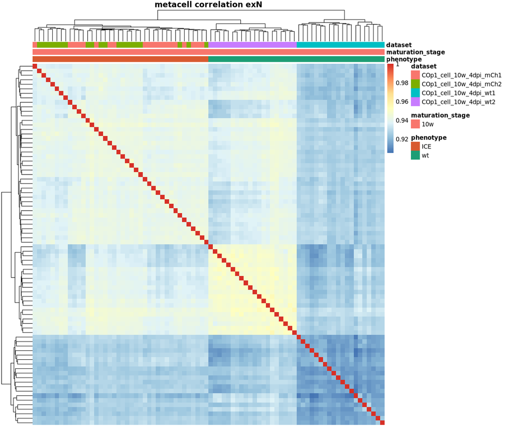

```r
sce_metacells_alldatasets_perCT_10w$exN$DESeq2_lst$heatmap
```

# GSEA per celltype | 10w

```r
gsea_10w = summarize_gsea_per_celltype(sce_metacells_alldatasets_perCT_10w, gs, params$gsea_n_pathways)

n_GOterms = list()
n_GOterms[["COp1_10w"]] = gsea_10w$goterm_summary
```

# Generate metacells + DEA | COp1 4m | per Celltype

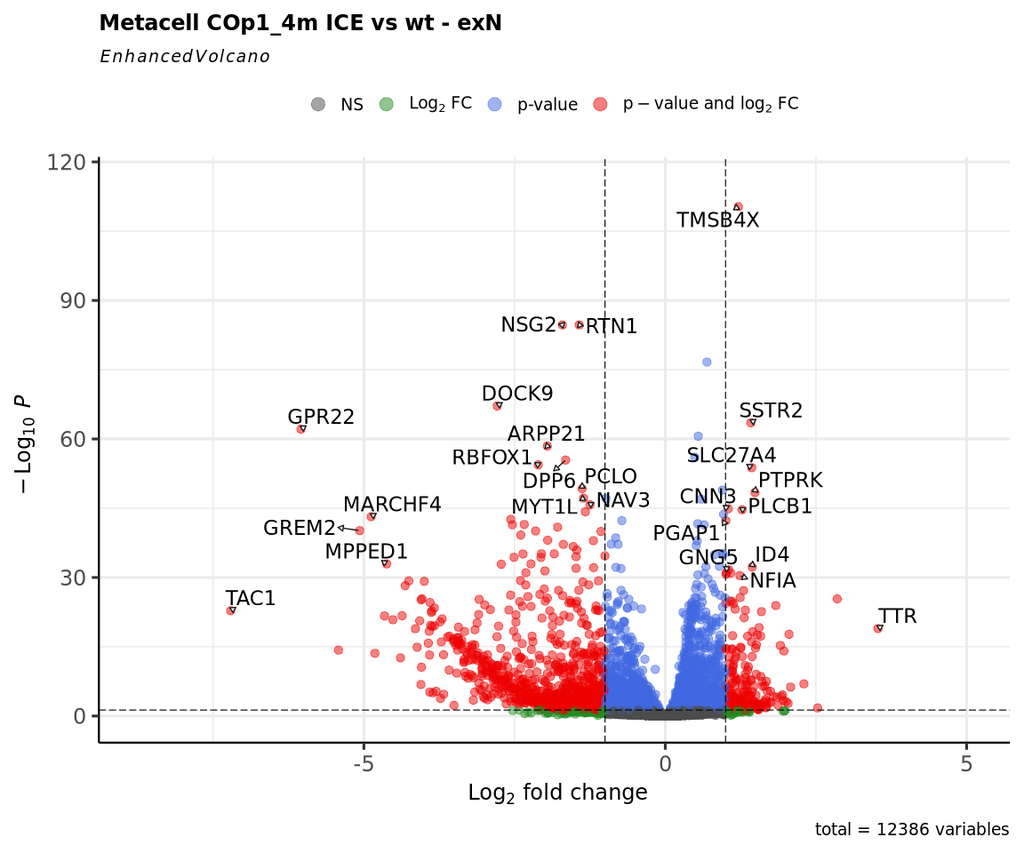

```r
celltypes = unique(harmonized_seurat_COp1_4m$Celltype)

sce_metacells_alldatasets_perCT_4m = generate_metacells_dea_per_celltype(
  harmonized_seurat_COp1_4m, celltypes, params$amount_of_cells_to_aggregate, params$n_metacells_generate
)

saveRDS(sce_metacells_alldatasets_perCT_4m , file.path(object_storage_path , "metacell_sce_allCelltypes_COp1_4m.RDS"))

markers = sce_metacells_alldatasets_perCT_4m$exN$markers
EnhancedVolcano(markers,
              lab = rownames(markers),
              x = 'avg_log2FC',
              y = 'padj',
              title = paste0('Metacell COp1_4m ICE vs wt - ', "exN"),
              pCutoff = 0.05,
              FCcutoff = 1,
              pointSize = 3.0,
              labSize = 6.0,
              drawConnectors = TRUE)
```

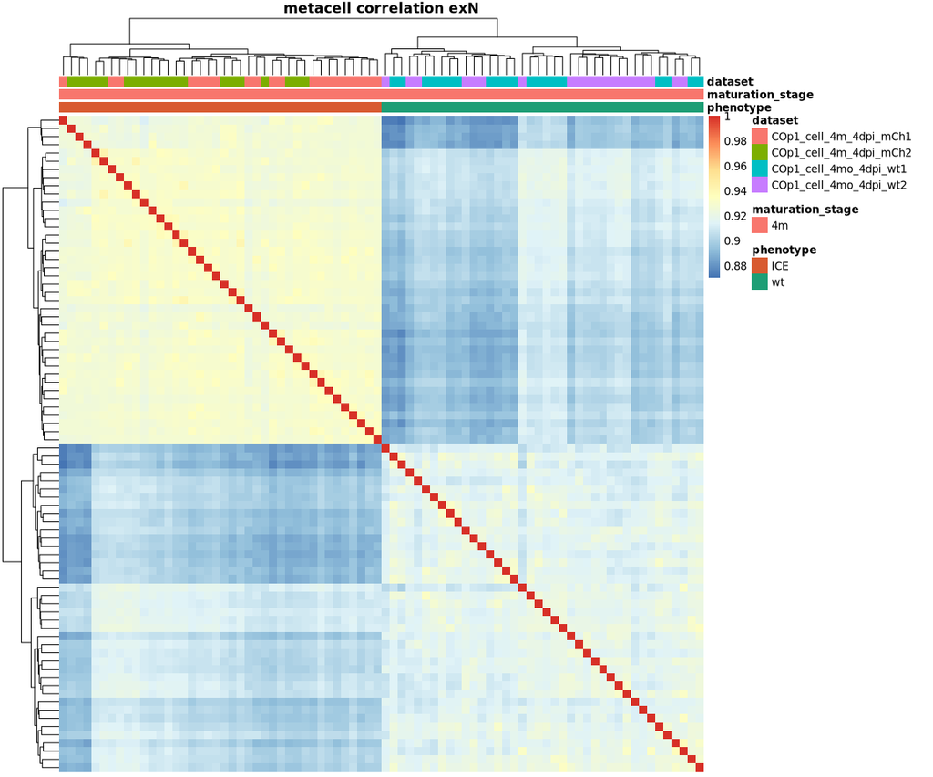

```r
sce_metacells_alldatasets_perCT_4m$exN$DESeq2_lst$heatmap
```

# GSEA per celltype | COp1 4m

```r
gsea_4m = summarize_gsea_per_celltype(sce_metacells_alldatasets_perCT_4m, gs, params$gsea_n_pathways)

n_GOterms[["COp1_4m"]] = gsea_4m$goterm_summary
```

# Generate metacells + DEA | COp2 | per Celltype

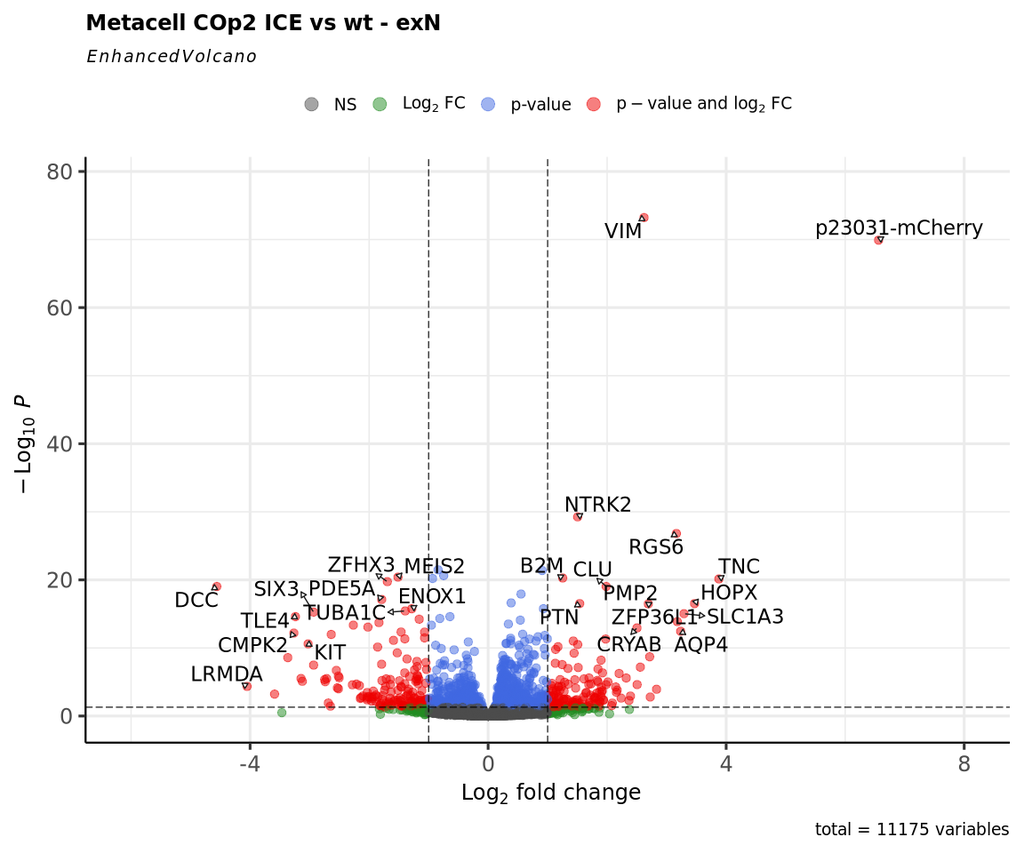

```r
celltypes = unique(harmonized_seurat_COp2_4dpi_4wpi$Celltype)

sce_metacells_alldatasets_perCT_COp2 = generate_metacells_dea_per_celltype(
  harmonized_seurat_COp2_4dpi_4wpi, celltypes, params$amount_of_cells_to_aggregate, params$n_metacells_generate
)

saveRDS(sce_metacells_alldatasets_perCT_COp2 , file.path(object_storage_path , "metacell_sce_allCelltypes_COp2.RDS"))

markers = sce_metacells_alldatasets_perCT_COp2$exN$markers
EnhancedVolcano(markers,
              lab = rownames(markers),
              x = 'avg_log2FC',
              y = 'padj',
              title = paste0('Metacell COp2 ICE vs wt - ', "exN"),
              pCutoff = 0.05,
              FCcutoff = 1,
              pointSize = 3.0,
              labSize = 6.0,
              drawConnectors = TRUE)
```

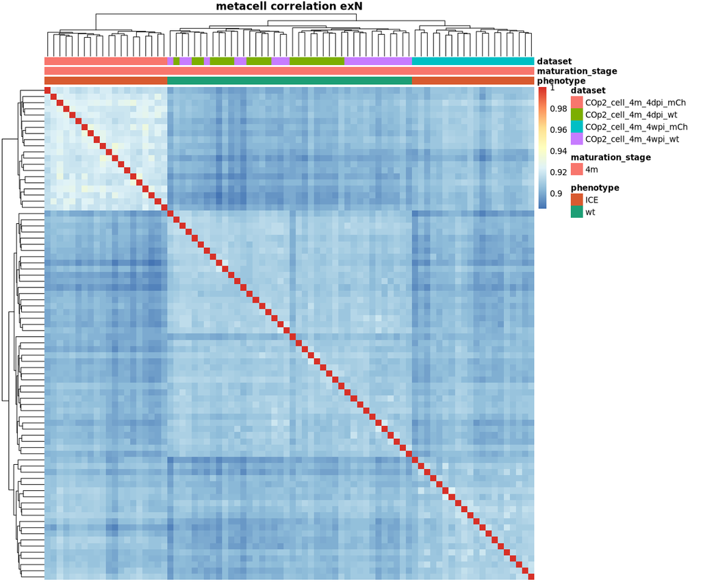

```r
sce_metacells_alldatasets_perCT_COp2$exN$DESeq2_lst$heatmap
```

# GSEA per celltype | COp2

```r
gsea_COp2 = summarize_gsea_per_celltype(sce_metacells_alldatasets_perCT_COp2, gs, params$gsea_n_pathways)

n_GOterms[["COp2"]] = gsea_COp2$goterm_summary
```

# plot relative amount of GOterms

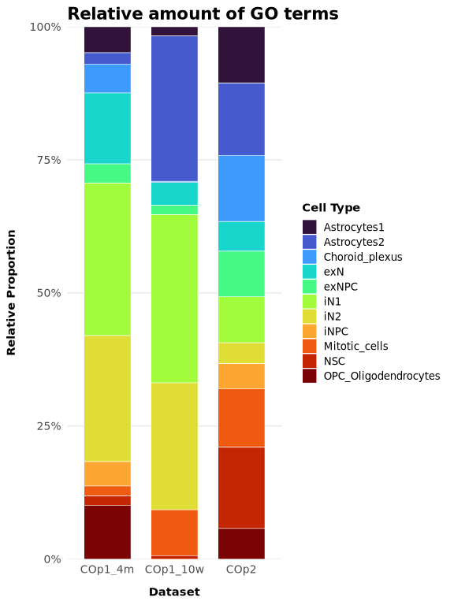

```r
plot_data_clean <- bind_rows(n_GOterms, .id = "Dataset") %>%
  mutate(Dataset = factor(Dataset, levels = c("COp1_4m", "COp1_10w", "COp2")))

# 2. Generate the polished plot
ggplot(plot_data_clean, aes(x = Dataset, y = relative_n, fill = celltype)) +
  geom_col(width = 0.7, color = "white", linewidth = 0.2) +
  scale_y_continuous(labels = scales::percent_format(), expand = c(0, 0)) +
  scale_fill_viridis_d(option = "turbo", direction = 1) +
  labs(
    title = "Relative amount of GO terms",
    y = "Relative Proportion",
    fill = "Cell Type"
  ) +
  theme_minimal(base_size = 13) +
  theme(
    panel.grid.major.x = element_blank(),
    panel.grid.minor = element_blank(),
    panel.grid.major.y = element_line(color = "gray92"),

    plot.title = element_text(face = "bold", size = 16, margin = margin(b = 4)),
    plot.subtitle = element_text(color = "gray40", size = 11, margin = margin(b = 15)),
    axis.title.x = element_text(margin = margin(t = 12), face = "bold", size = 11),
    axis.title.y = element_text(margin = margin(r = 12), face = "bold", size = 11),

    legend.title = element_text(face = "bold", size = 11),
    legend.text = element_text(size = 10),
    legend.key.size = unit(0.5, "cm")
  )
```

# Save metacells | COp1_10w | IN/EN

**This is used for prediction**

```r
saveRDS(sce_metacells_alldatasets_perCT_10w$iN1$sce, file.path(object_storage_path , "metacell_sce_IN_organoids_COp1_10w.RDS"))
saveRDS(sce_metacells_alldatasets_perCT_10w$exN$sce, file.path(object_storage_path , "metacell_sce_EN_organoids_COp1_10w.RDS"))
```

**Here we are trying to understand if phenotype is a variable that can explain the variability in the data**

**DEA IN**

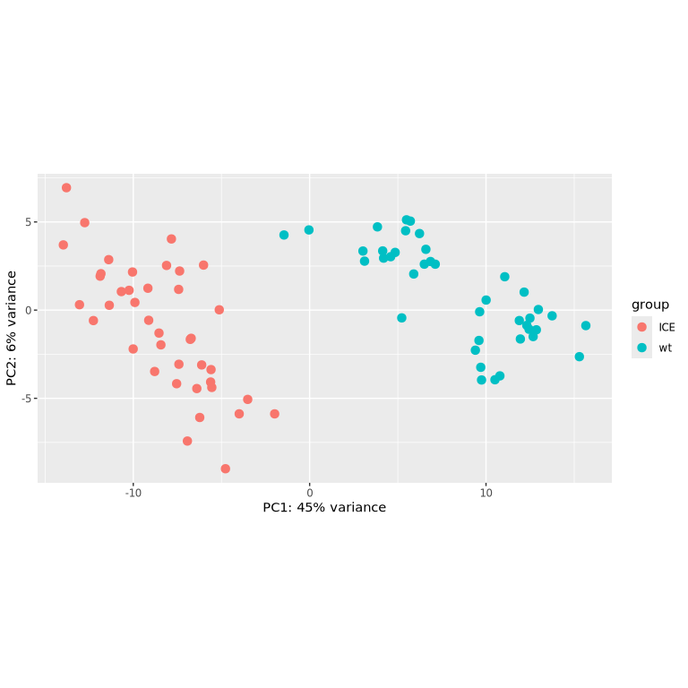

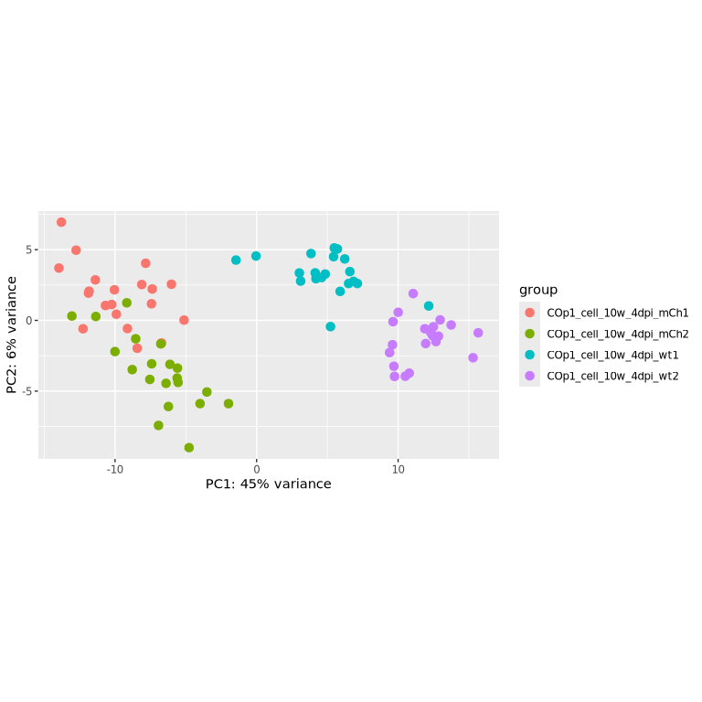

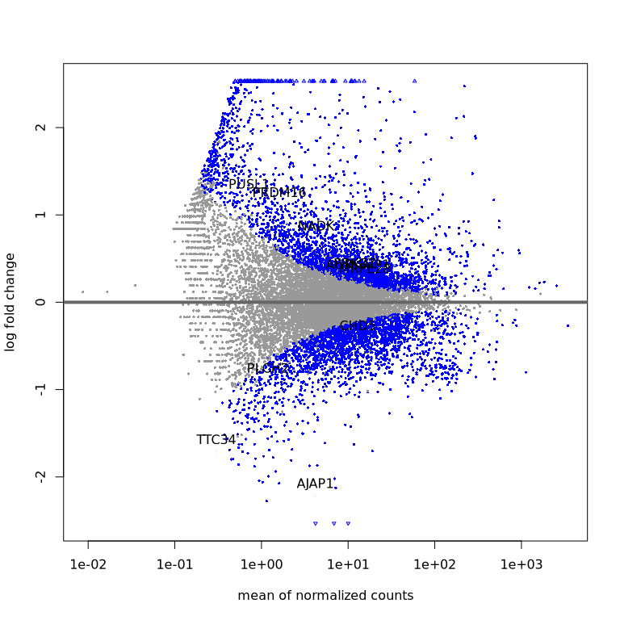

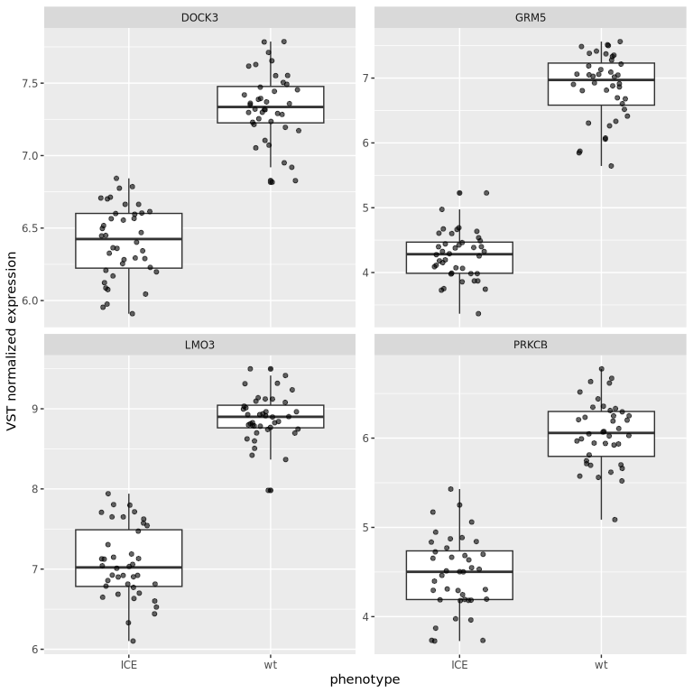

```r
markers = plot_dea_tab(
  sce_metacells_alldatasets_perCT_10w$iN1$DESeq2_lst,
  file.path(DEA_results_path , "DEA_metacell_ICE_vs_wt_iN_COp1_10w_organoids.csv")
)
```

**DEA EN**

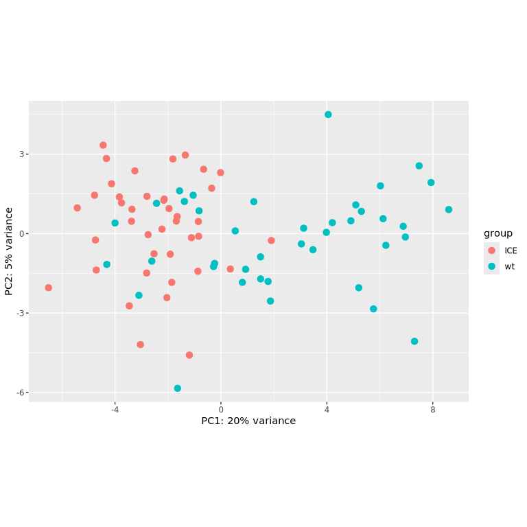

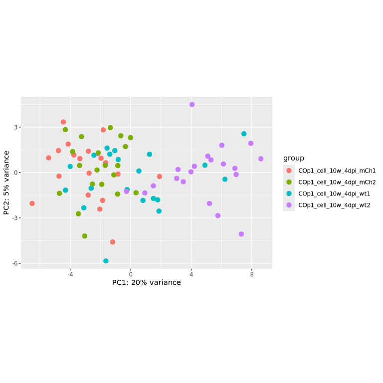

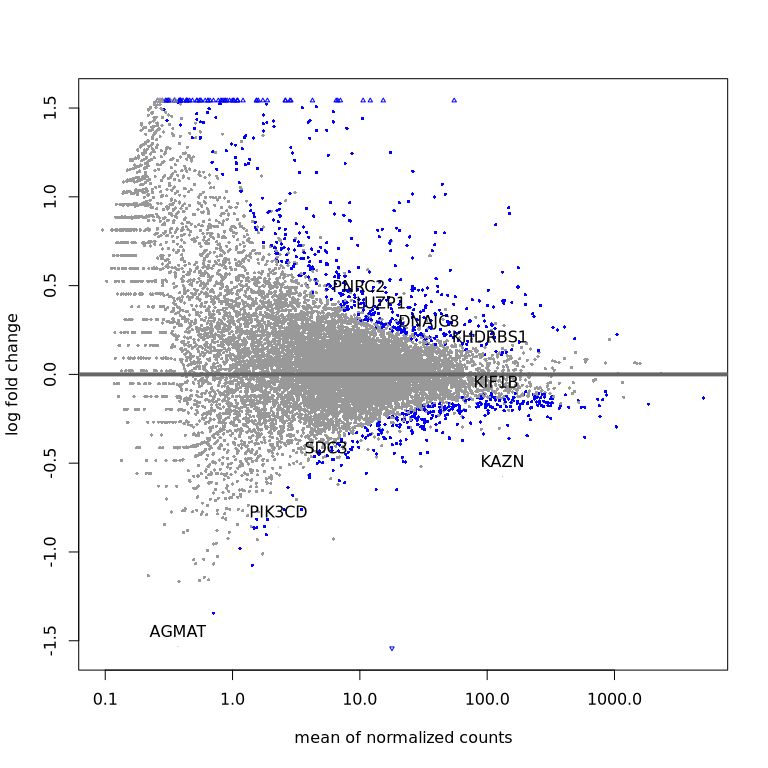

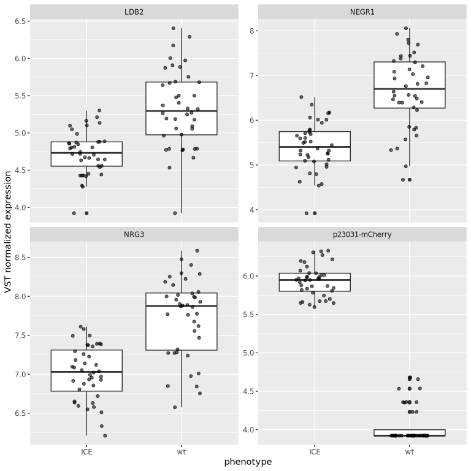

```r
markers = plot_dea_tab(
  sce_metacells_alldatasets_perCT_10w$exN$DESeq2_lst,
  file.path(DEA_results_path , "DEA_metacell_ICE_vs_wt_exN_COp1_10w_organoids.csv")
)
```

**GSEA IN**

```
preparing gene to GO mapping data...
```

```
preparing IC data...
```

```
preparing gene to GO mapping data...
```

```
preparing IC data...
```

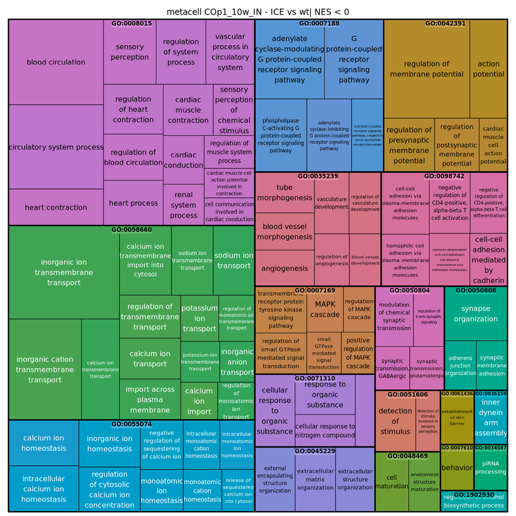

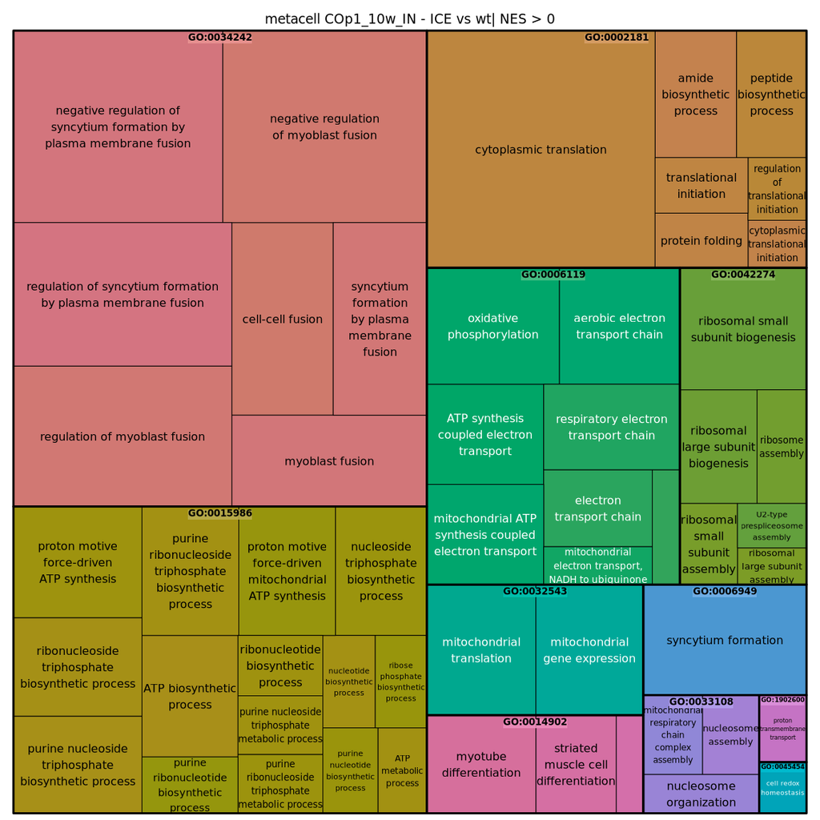

```r
x = run_gsea_tab(
  markers_csv_path = file.path(DEA_results_path , "DEA_metacell_ICE_vs_wt_iN_COp1_10w_organoids.csv"),
  gs = gs, n_pathways = params$gsea_n_pathways,
  up_txt_path = file.path(gsea_results_path , "GOterms_metacell_ICE_vs_wt_COp1_10w_iN_upregulated_ICE_organoids.txt"),
  down_txt_path = file.path(gsea_results_path , "GOterms_metacell_ICE_vs_wt_COp1_10w_iN_downregulated_ICE_organoids.txt"),
  title_label = "metacell COp1_10w_IN - ICE vs wt"
)
```

**GSEA EN**

```
preparing gene to GO mapping data...
```

```
preparing IC data...
```

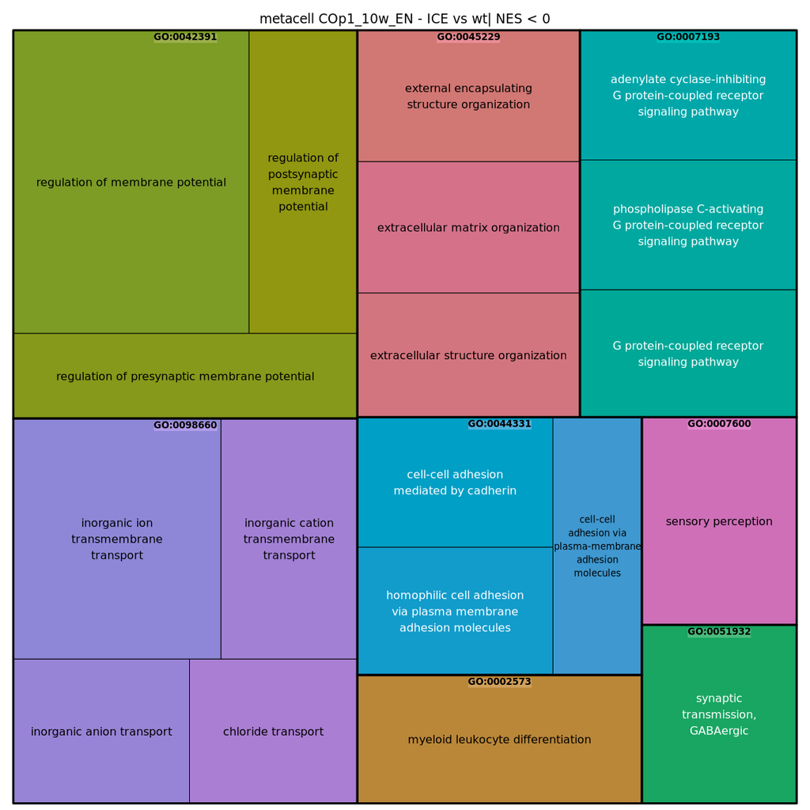

```r
x = run_gsea_tab(
  markers_csv_path = file.path(DEA_results_path , "DEA_metacell_ICE_vs_wt_exN_COp1_10w_organoids.csv"),
  gs = gs, n_pathways = params$gsea_n_pathways,
  up_txt_path = file.path(gsea_results_path , "GOterms_metacell_ICE_vs_wt_COp1_10w_exN_upregulated_ICE_organoids.txt"),
  down_txt_path = file.path(gsea_results_path , "GOterms_metacell_ICE_vs_wt_COp1_10w_exN_downregulated_ICE_organoids.txt"),
  title_label = "metacell COp1_10w_EN - ICE vs wt"
)
```

# Save metacells | COp1_4m | IN/EN

**This is used for prediction**

```r
saveRDS(sce_metacells_alldatasets_perCT_4m$iN1$sce, file.path(object_storage_path , "metacell_sce_IN_organoids_COp1_4m.RDS"))
saveRDS(sce_metacells_alldatasets_perCT_4m$exN$sce, file.path(object_storage_path , "metacell_sce_EN_organoids_COp1_4m.RDS"))
```

**DEA IN**

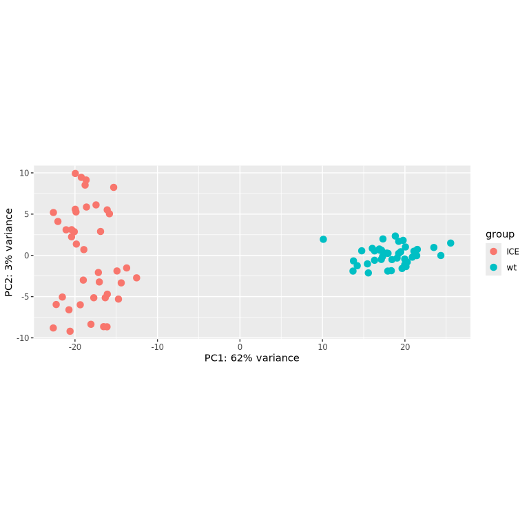

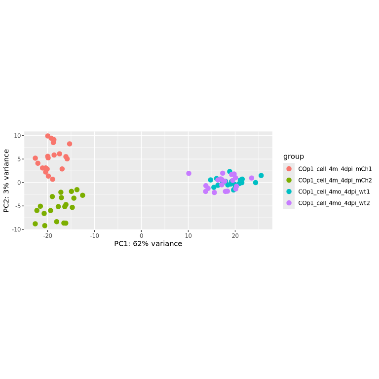

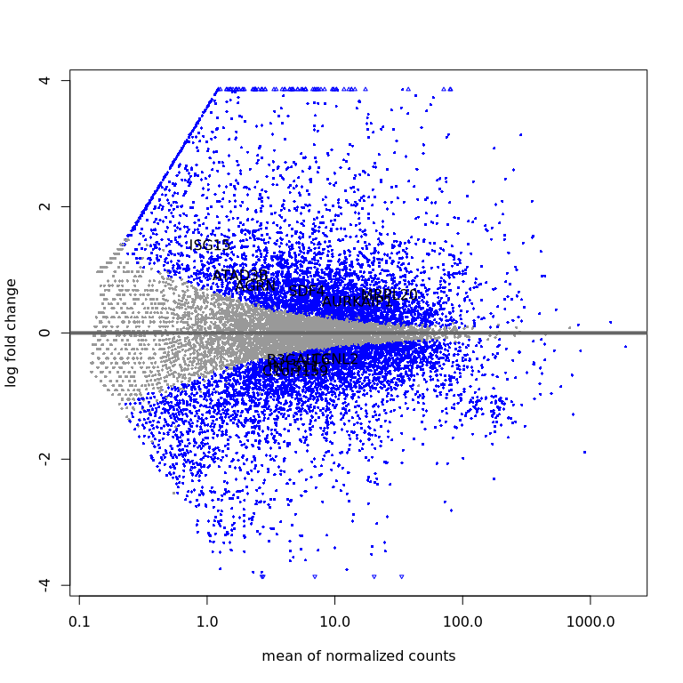

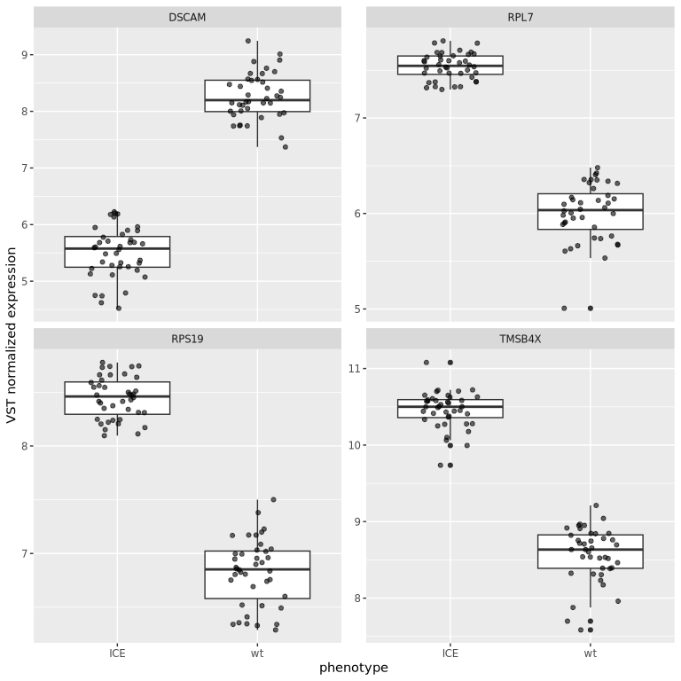

```r
markers = plot_dea_tab(
  sce_metacells_alldatasets_perCT_4m$iN1$DESeq2_lst,
  file.path(DEA_results_path , "DEA_metacell_ICE_vs_wt_iN_COp1_4m_organoids.csv")
)
```

**DEA EN**

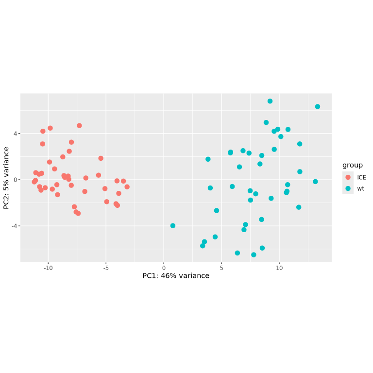

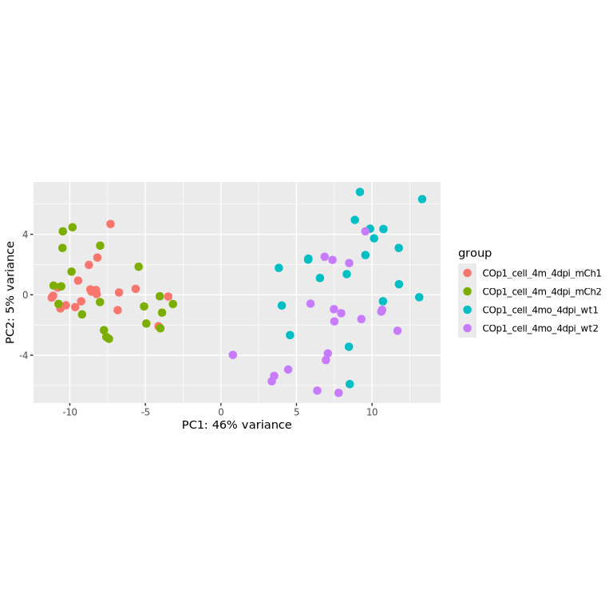

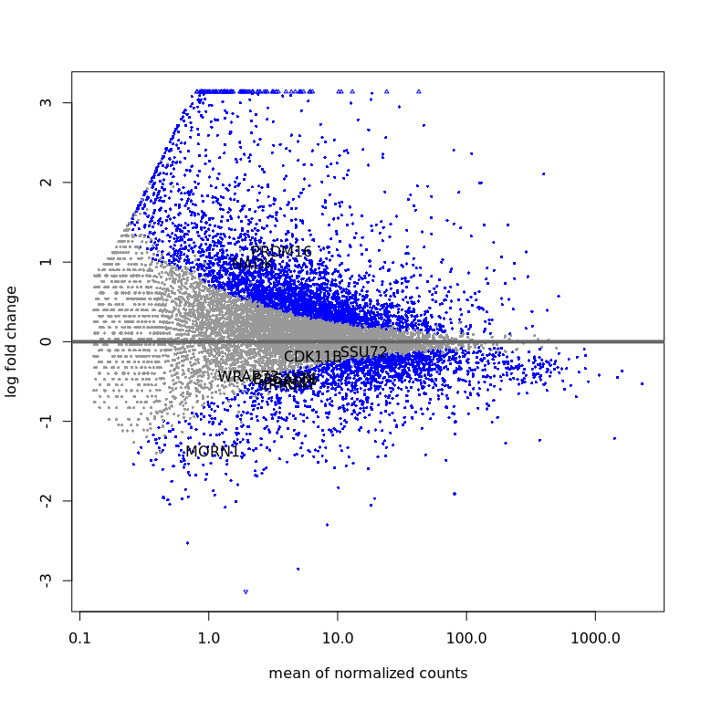

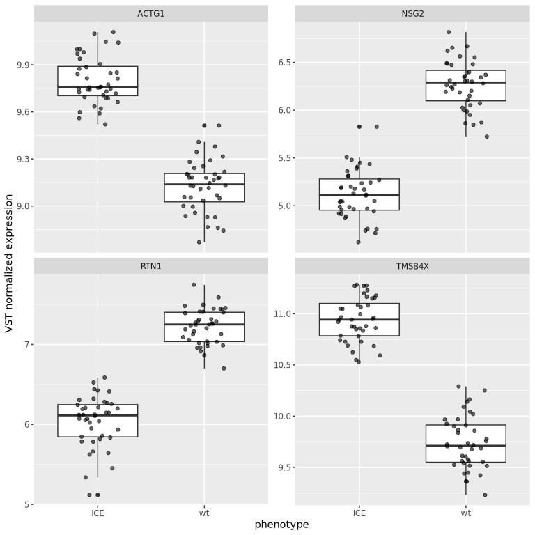

```r
markers = plot_dea_tab(
  sce_metacells_alldatasets_perCT_4m$exN$DESeq2_lst,
  file.path(DEA_results_path , "DEA_metacell_ICE_vs_wt_exN_COp1_4m_organoids.csv")
)
```

**GSEA IN**

```
preparing gene to GO mapping data...
```

```
preparing IC data...
```

```
preparing gene to GO mapping data...
```

```
preparing IC data...
```

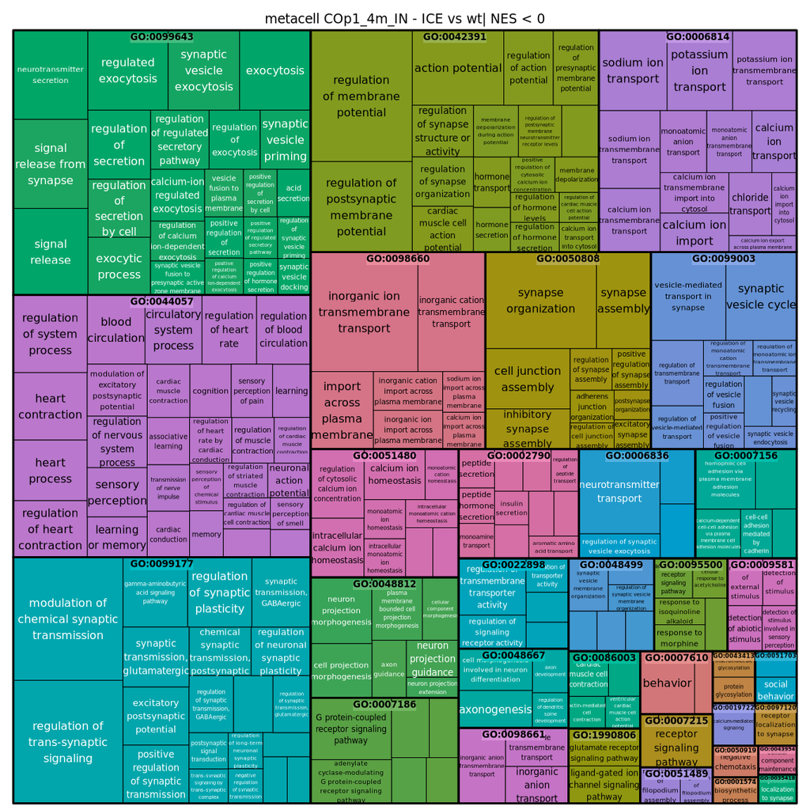

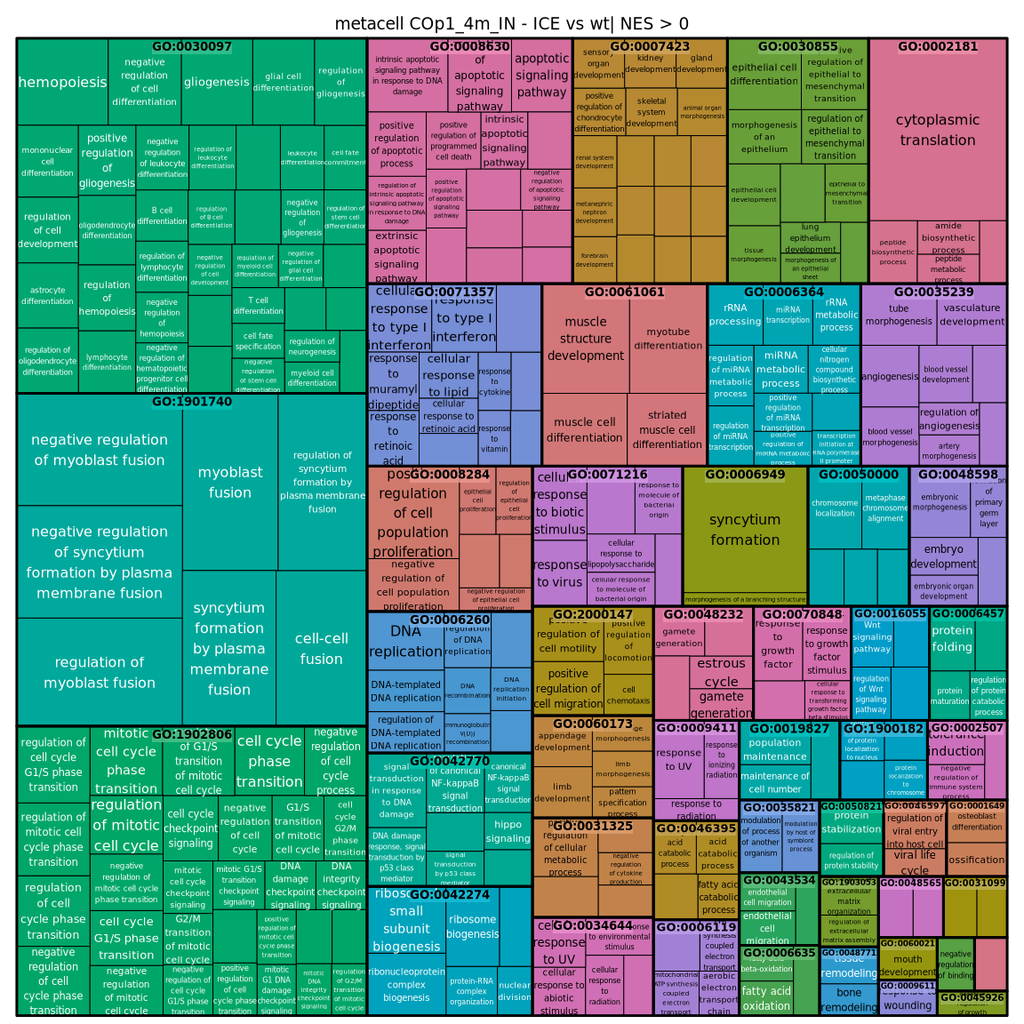

```r
x = run_gsea_tab(
  markers_csv_path = file.path(DEA_results_path , "DEA_metacell_ICE_vs_wt_iN_COp1_4m_organoids.csv"),
  gs = gs, n_pathways = params$gsea_n_pathways,
  up_txt_path = file.path(gsea_results_path , "GOterms_metacell_ICE_vs_wt_COp1_4m_iN_upregulated_ICE_organoids.txt"),
  down_txt_path = file.path(gsea_results_path , "GOterms_metacell_ICE_vs_wt_COp1_4m_iN_downregulated_ICE_organoids.txt"),
  title_label = "metacell COp1_4m_IN - ICE vs wt"
)
```

**GSEA EN**

```
preparing gene to GO mapping data...
```

```
preparing IC data...
```

```
preparing gene to GO mapping data...
```

```
preparing IC data...
```

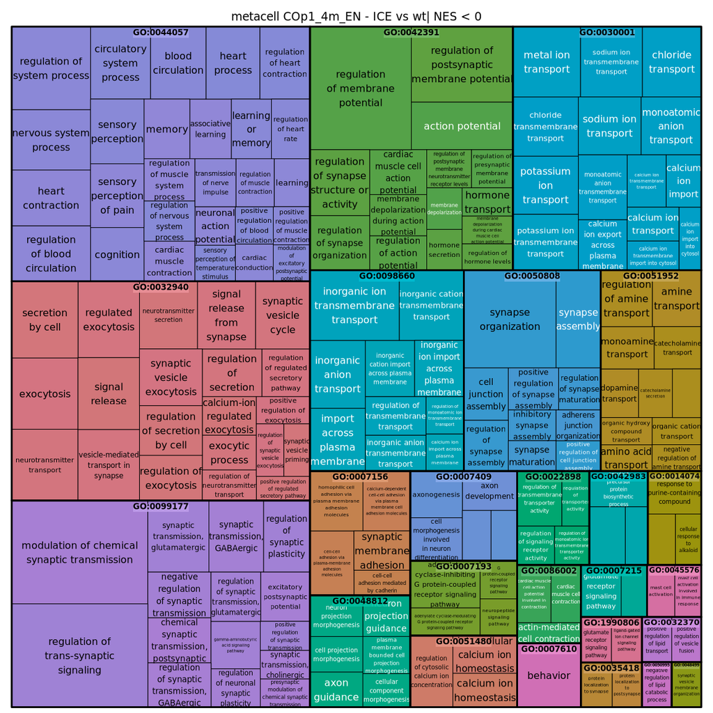

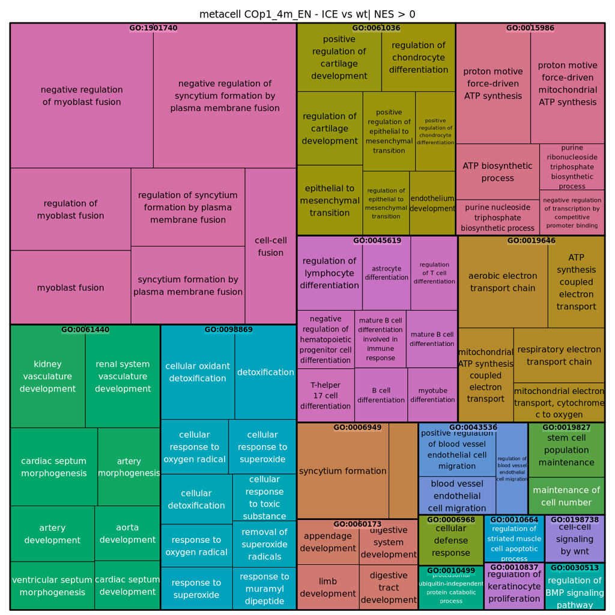

```r
x = run_gsea_tab(
  markers_csv_path = file.path(DEA_results_path , "DEA_metacell_ICE_vs_wt_exN_COp1_4m_organoids.csv"),
  gs = gs, n_pathways = params$gsea_n_pathways,
  up_txt_path = file.path(gsea_results_path , "GOterms_metacell_ICE_vs_wt_COp1_4m_exN_upregulated_ICE_organoids.txt"),
  down_txt_path = file.path(gsea_results_path , "GOterms_metacell_ICE_vs_wt_COp1_4m_exN_downregulated_ICE_organoids.txt"),
  title_label = "metacell COp1_4m_EN - ICE vs wt"
)
```

# Generate metacell | COp2 4dpi | IN/EN

This is used for prediction

```r
sce_metacells_COp2_4dpi = generate_metacell_by_timepoint(
  harmonized_seurat_COp2_4dpi_4wpi, c("iN1", "exN"), "4dpi",
  params$amount_of_cells_to_aggregate, params$n_metacells_generate,
  file.path(DEA_results_path, "DEA_metacell_ICE_vs_wt")
)

saveRDS(sce_metacells_COp2_4dpi$iN1, file.path(object_storage_path , "metacell_sce_IN_organoids_COp2_4dpi.RDS"))
saveRDS(sce_metacells_COp2_4dpi$exN, file.path(object_storage_path , "metacell_sce_EN_organoids_COp2_4dpi.RDS"))
```

# Generate metacell | COp2 4wpi | IN/EN

This is used for prediction

```r
sce_metacells_COp2_4wpi = generate_metacell_by_timepoint(
  harmonized_seurat_COp2_4dpi_4wpi, c("iN1", "exN"), "4wpi",
  params$amount_of_cells_to_aggregate, params$n_metacells_generate,
  file.path(DEA_results_path, "DEA_metacell_ICE_vs_wt")
)

saveRDS(sce_metacells_COp2_4wpi$iN1, file.path(object_storage_path , "metacell_sce_IN_organoids_COp2_4wpi.RDS"))
saveRDS(sce_metacells_COp2_4wpi$exN, file.path(object_storage_path , "metacell_sce_EN_organoids_COp2_4wpi.RDS"))
```

# DEA | all celltypes + all datasets together

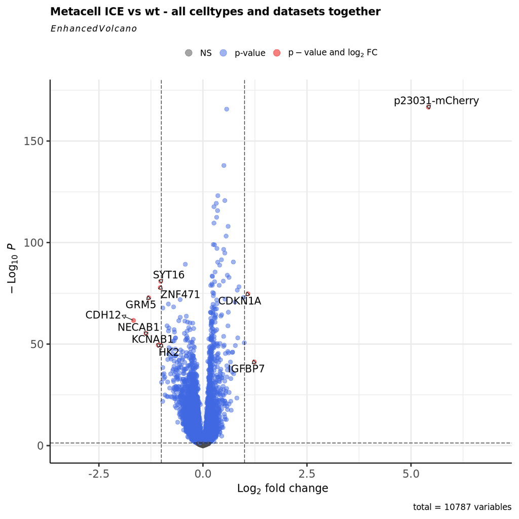

```r
all_datasets = list(
  "10w" = sce_metacells_alldatasets_perCT_10w,
  "4m"  = sce_metacells_alldatasets_perCT_4m,
  "COp2" = sce_metacells_alldatasets_perCT_COp2
)

all_celltypes = unique(unlist(lapply(all_datasets, names)))

# For each celltype, pull its sce from every dataset it appears in, tag which dataset
# it came from, and merge those together on their shared genes.
merged_list_by_celltype = lapply(all_celltypes, function(ct) {
  sce_elements = lapply(names(all_datasets), function(ds_name) {
    sce_obj = all_datasets[[ds_name]][[ct]]$sce
    if (is.null(sce_obj)) return(NULL)
    colData(sce_obj)$dataset_batch = ds_name
    sce_obj
  })
  sce_elements = Filter(Negate(is.null), sce_elements)
  merge_sces_common_genes(sce_elements)
}) %>% setNames(all_celltypes)

# Merge every celltype's combined object together, again restricted to shared genes
master_merged_sce = merge_sces_common_genes(merged_list_by_celltype)

DESeq2_lst = metacell_DESeq2_DEA(sce = master_merged_sce, phenotype_column = "phenotype", dataset_column = "dataset", design_formula = as.formula("~ maturation_stage + Protocol + Celltype + phenotype"), title_corHeatmap = "metacell correlation across all datasets and all celltypes", contrast = c("phenotype", "ICE", "wt"), organism = "organoid")

markers = DESeq2_lst$markers %>% na.omit()

EnhancedVolcano(markers,
              lab = rownames(markers),
              x = 'avg_log2FC',
              y = 'padj',
              title = 'Metacell ICE vs wt - all celltypes and datasets together',
              pCutoff = 0.05,
              FCcutoff = 1,
              pointSize = 3.0,
              labSize = 6.0,
              drawConnectors = TRUE)
```

# DEA | neurons + all datasets together

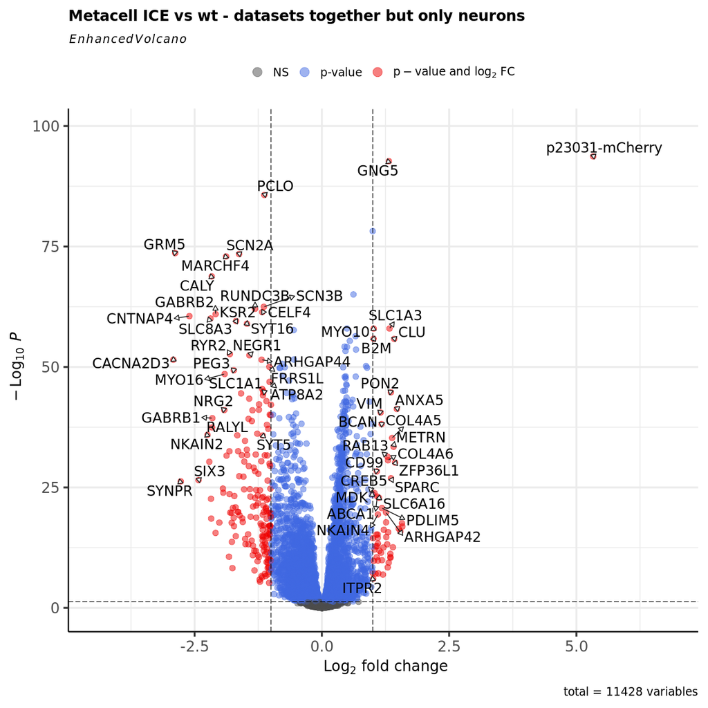

```r
all_datasets_neurons = list(
  "EN_10w" = sce_metacells_alldatasets_perCT_10w$exN$sce,
  "IN_10w" = sce_metacells_alldatasets_perCT_10w$iN1$sce,
  "EN_4m" = sce_metacells_alldatasets_perCT_4m$exN$sce,
  "IN_4m" = sce_metacells_alldatasets_perCT_4m$iN1$sce,
  "EN_COp2" = sce_metacells_alldatasets_perCT_COp2$exN$sce,
  "IN_COp2" = sce_metacells_alldatasets_perCT_COp2$iN1$sce)

master_merged_sce = merge_sces_common_genes(all_datasets_neurons)

DESeq2_lst = metacell_DESeq2_DEA(sce = master_merged_sce, phenotype_column = "phenotype", dataset_column = "dataset", design_formula = as.formula("~ maturation_stage + Protocol + Celltype + phenotype"), title_corHeatmap = "metacell correlation across all datasets but only neurons", contrast = c("phenotype", "ICE", "wt"), organism = "organoid")

markers = DESeq2_lst$markers %>% na.omit()

write.csv(markers, file.path(DEA_results_path , "DEA_metacell_ICE_vs_wt_onlyneurons_allDatasets_organoids.csv"))

EnhancedVolcano(markers,
              lab = rownames(markers),
              x = 'avg_log2FC',
              y = 'padj',
              title = 'Metacell ICE vs wt - datasets together but only neurons',
              pCutoff = 0.05,
              FCcutoff = 1,
              pointSize = 3.0,
              labSize = 6.0,
              drawConnectors = TRUE)
```